# Week-13-IP-unsupervised

# Exploratory Data Analysis

## Univariate analysis

### Measures of central tendency

```r
# previewing the numerical columns
colnames(df1)
```

```
##  [1] "Administrative"          "Administrative_Duration"
##  [3] "Informational"           "Informational_Duration"
##  [5] "ProductRelated"          "ProductRelated_Duration"
##  [7] "BounceRates"             "ExitRates"
##  [9] "PageValues"              "SpecialDay"
## [11] "OperatingSystems"        "Browser"
## [13] "Region"                  "TrafficType"
```

```r
# Getting a summary of descriptive statistics
library(psych)
describe(df1)
```

```
##                         vars     n    mean      sd median trimmed    mad min
## Administrative             1 12316    2.32    3.32   1.00    1.63   1.48   0
## Administrative_Duration    2 12316   80.91  176.86   8.00   42.19  11.86  -1
## Informational              3 12316    0.50    1.27   0.00    0.18   0.00   0
## Informational_Duration     4 12316   34.51  140.83   0.00    3.60   0.00  -1
## ProductRelated             5 12316   31.76   44.49  18.00   22.78  19.27   0
## ProductRelated_Duration    6 12316 1196.04 1914.37 599.77  821.41 743.05  -1
## BounceRates                7 12316    0.02    0.05   0.00    0.01   0.00   0
## ExitRates                  8 12316    0.04    0.05   0.03    0.03   0.02   0
## PageValues                 9 12316    5.90   18.58   0.00    1.30   0.00   0
## SpecialDay                10 12316    0.06    0.20   0.00    0.00   0.00   0
## OperatingSystems          11 12316    2.12    0.91   2.00    2.06   0.00   1
## Browser                   12 12316    2.36    1.72   2.00    2.00   0.00   1
## Region                    13 12316    3.15    2.40   3.00    2.79   2.97   1
## TrafficType               14 12316    4.07    4.02   2.00    3.22   1.48   1
##                              max    range skew kurtosis    se
## Administrative             27.00    27.00 1.96     4.69  0.03
## Administrative_Duration  3398.75  3399.75 5.61    50.48  1.59
## Informational              24.00    24.00 4.03    26.89  0.01
## Informational_Duration   2549.38  2550.38 7.57    76.18  1.27
## ProductRelated            705.00   705.00 4.34    31.17  0.40
## ProductRelated_Duration 63973.52 63974.52 7.26   137.03 17.25
## BounceRates                 0.20     0.20 2.95     7.75  0.00
## ExitRates                   0.20     0.20 2.15     4.04  0.00
## PageValues                361.76   361.76 6.38    65.53  0.17
## SpecialDay                  1.00     1.00 3.30     9.89  0.00
## OperatingSystems            8.00     7.00 2.07    10.45  0.01
## Browser                    13.00    12.00 3.24    12.73  0.02
## Region                      9.00     8.00 0.98    -0.15  0.02
## TrafficType                20.00    19.00 1.96     3.48  0.04
```

### Univariate graphical EDA

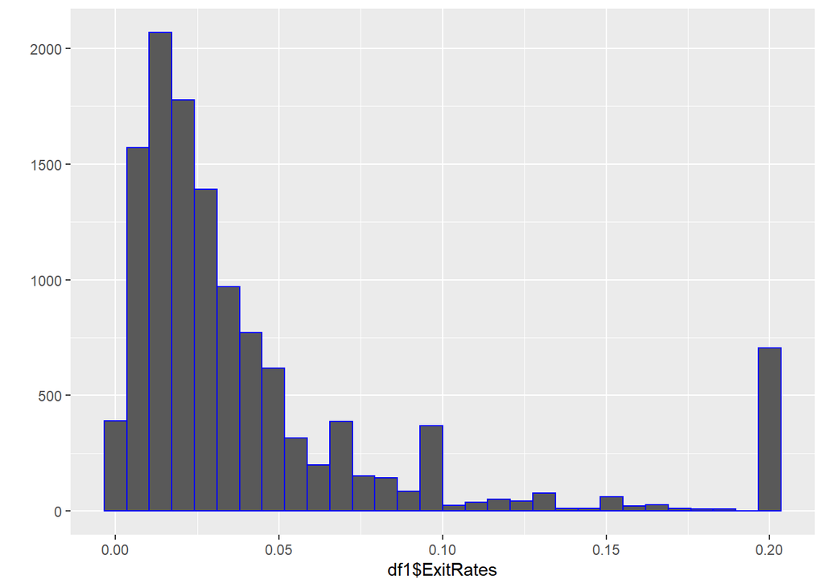

```r
library(ggplot2)
# Histogram of showing exit rates.
qplot(data=df1, x=df1$ExitRates, colour=I("blue"))
```

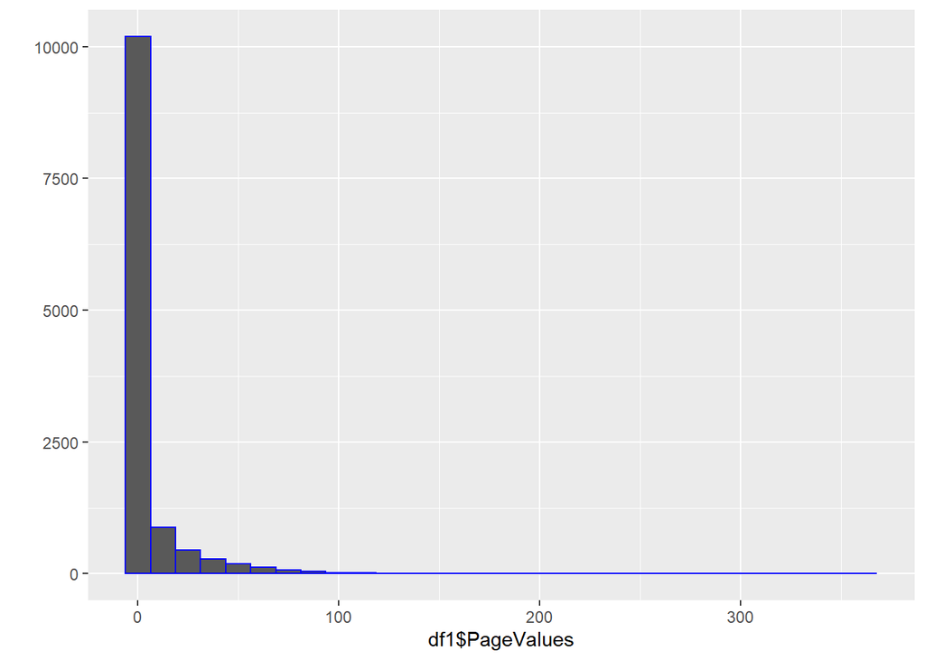

```r
# Histogram of showing distribution of page values.
qplot(data=df1, x=df1$PageValues, colour=I("blue"))
```

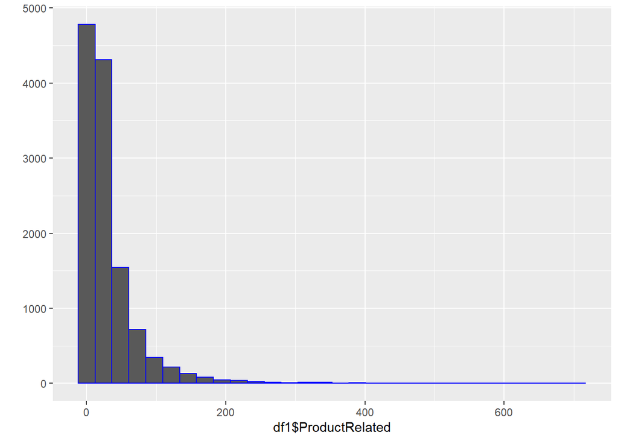

```r
# Histogram of showing distribution of prouct related visits.
qplot(data=df1, x=df1$ProductRelated, colour=I("blue"))
```

The product related visit values were mostly concentrated between 0 and 200.

## Bivariate analysis

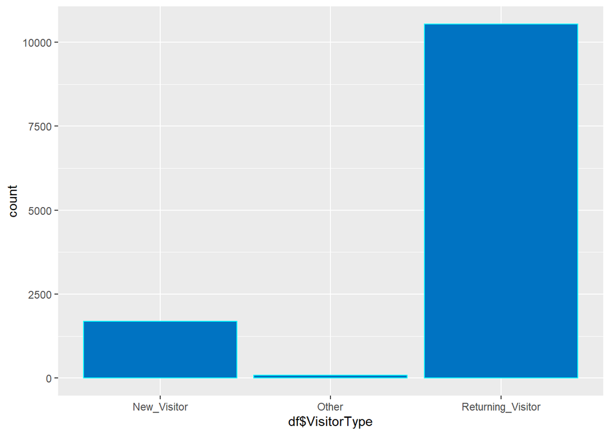

```r
# bargraph showing Visitor types.
ggplot(data = df, aes(x = df$VisitorType)) +  geom_bar(fill = "#0073C2FF", color = 'cyan')
```

Majority of the visitors on the sites were return visitors. There was also a considerable number of new visitors.

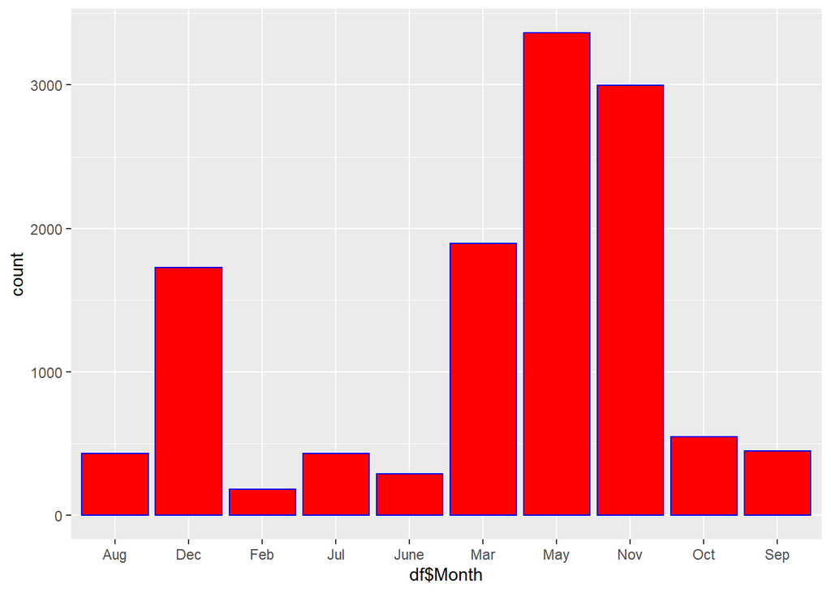

```r
# # bargraph showing monthly site visits.
ggplot(data = df, aes(x = df$Month)) +  geom_bar(fill = "red", color = 'blue')
```

People were most active on the sites during the months of May followed closely by November then March and December.

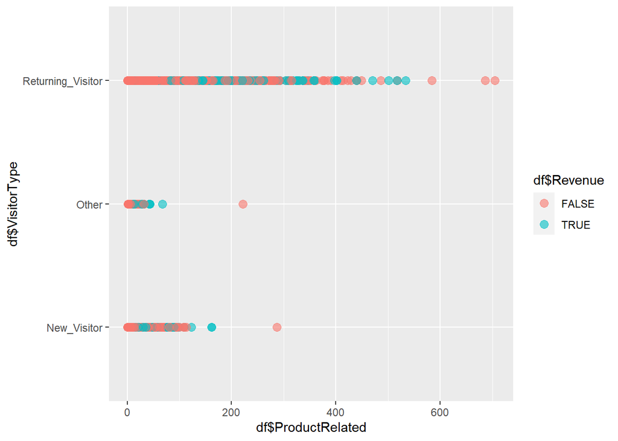

```r
# Relationship between visitor type and revenue
ggplot(data = df) +
    geom_point(aes(x = df$ProductRelated, y = df$VisitorType, color = df$Revenue ), size = 3, alpha = 0.6)
```

# Building the prediction models

## Hierarchical clustering

```r
head(df)
```

```
##   Administrative Administrative_Duration Informational Informational_Duration
## 1              0                       0             0                      0
## 2              0                       0             0                      0
## 3              0                      -1             0                     -1
## 4              0                       0             0                      0
## 5              0                       0             0                      0
## 6              0                       0             0                      0
##   ProductRelated ProductRelated_Duration BounceRates ExitRates PageValues
## 1              1                0.000000  0.20000000 0.2000000          0
## 2              2               64.000000  0.00000000 0.1000000          0
## 3              1               -1.000000  0.20000000 0.2000000          0
## 4              2                2.666667  0.05000000 0.1400000          0
## 5             10              627.500000  0.02000000 0.0500000          0
## 6             19              154.216667  0.01578947 0.0245614          0
##   SpecialDay Month OperatingSystems Browser Region TrafficType
## 1          0   Feb                1       1      1           1
## 2          0   Feb                2       2      1           2
## 3          0   Feb                4       1      9           3
## 4          0   Feb                3       2      2           4
## 5          0   Feb                3       3      1           4
## 6          0   Feb                2       2      1           3
##         VisitorType Weekend Revenue
## 1 Returning_Visitor   FALSE   FALSE
## 2 Returning_Visitor   FALSE   FALSE
## 3 Returning_Visitor   FALSE   FALSE
## 4 Returning_Visitor   FALSE   FALSE
## 5 Returning_Visitor    TRUE   FALSE
## 6 Returning_Visitor   FALSE   FALSE
```

```r
str(df)
```

```
## 'data.frame':    12316 obs. of  18 variables:
##  $ Administrative         : int  0 0 0 0 0 0 0 1 0 0 ...
##  $ Administrative_Duration: num  0 0 -1 0 0 0 -1 -1 0 0 ...
##  $ Informational          : int  0 0 0 0 0 0 0 0 0 0 ...
##  $ Informational_Duration : num  0 0 -1 0 0 0 -1 -1 0 0 ...
##  $ ProductRelated         : int  1 2 1 2 10 19 1 1 2 3 ...
##  $ ProductRelated_Duration: num  0 64 -1 2.67 627.5 ...
##  $ BounceRates            : num  0.2 0 0.2 0.05 0.02 ...
##  $ ExitRates              : num  0.2 0.1 0.2 0.14 0.05 ...
##  $ PageValues             : num  0 0 0 0 0 0 0 0 0 0 ...
##  $ SpecialDay             : num  0 0 0 0 0 0 0.4 0 0.8 0.4 ...
##  $ Month                  : chr  "Feb" "Feb" "Feb" "Feb" ...
##  $ OperatingSystems       : int  1 2 4 3 3 2 2 1 2 2 ...
##  $ Browser                : int  1 2 1 2 3 2 4 2 2 4 ...
##  $ Region                 : int  1 1 9 2 1 1 3 1 2 1 ...
##  $ TrafficType            : int  1 2 3 4 4 3 3 5 3 2 ...
##  $ VisitorType            : chr  "Returning_Visitor" "Returning_Visitor" "Returning_Visitor" "Returning_Visitor" ...
##  $ Weekend                : logi  FALSE FALSE FALSE FALSE TRUE FALSE ...
##  $ Revenue                : logi  FALSE FALSE FALSE FALSE FALSE FALSE ...
##  - attr(*, "na.action")= 'omit' Named int [1:14] 1066 1133 1134 1135 1136 1137 1474 1475 1476 1477 ...
##   ..- attr(*, "names")= chr [1:14] "1066" "1133" "1134" "1135" ...
```

```r
# converting character columns to numeric
char_columns <- sapply(df, is.character)             # Identify character columns
df_chars_as_num <- df
# Replicate
df_chars_as_num[ , char_columns] <- as.data.frame(apply(df_chars_as_num[ , char_columns], 2, as.numeric))
sapply(df_chars_as_num, class)
```

```
##          Administrative Administrative_Duration           Informational
##               "integer"               "numeric"               "integer"
##  Informational_Duration          ProductRelated ProductRelated_Duration
##               "numeric"               "integer"               "numeric"
##             BounceRates               ExitRates              PageValues
##               "numeric"               "numeric"               "numeric"
##              SpecialDay                   Month        OperatingSystems
##               "numeric"               "numeric"               "integer"
##                 Browser                  Region             TrafficType
##               "integer"               "integer"               "integer"
##             VisitorType                 Weekend                 Revenue
##               "numeric"               "logical"               "logical"
```

```r
df$VisitorType  <- as.numeric(as.logical(df$VisitorType))
df$Month   <- as.numeric(as.character(df$Month))
df$Weekend   <- as.numeric(as.logical(df$Weekend))
```

```r
str(df)
```

```
## 'data.frame':    12316 obs. of  18 variables:
##  $ Administrative         : int  0 0 0 0 0 0 0 1 0 0 ...
##  $ Administrative_Duration: num  0 0 -1 0 0 0 -1 -1 0 0 ...
##  $ Informational          : int  0 0 0 0 0 0 0 0 0 0 ...
##  $ Informational_Duration : num  0 0 -1 0 0 0 -1 -1 0 0 ...
##  $ ProductRelated         : int  1 2 1 2 10 19 1 1 2 3 ...
##  $ ProductRelated_Duration: num  0 64 -1 2.67 627.5 ...
##  $ BounceRates            : num  0.2 0 0.2 0.05 0.02 ...
##  $ ExitRates              : num  0.2 0.1 0.2 0.14 0.05 ...
##  $ PageValues             : num  0 0 0 0 0 0 0 0 0 0 ...
##  $ SpecialDay             : num  0 0 0 0 0 0 0.4 0 0.8 0.4 ...
##  $ Month                  : num  NA NA NA NA NA NA NA NA NA NA ...
##  $ OperatingSystems       : int  1 2 4 3 3 2 2 1 2 2 ...
##  $ Browser                : int  1 2 1 2 3 2 4 2 2 4 ...
##  $ Region                 : int  1 1 9 2 1 1 3 1 2 1 ...
##  $ TrafficType            : int  1 2 3 4 4 3 3 5 3 2 ...
##  $ VisitorType            : num  NA NA NA NA NA NA NA NA NA NA ...
##  $ Weekend                : num  0 0 0 0 1 0 0 1 0 0 ...
##  $ Revenue                : logi  FALSE FALSE FALSE FALSE FALSE FALSE ...
##  - attr(*, "na.action")= 'omit' Named int [1:14] 1066 1133 1134 1135 1136 1137 1474 1475 1476 1477 ...
##   ..- attr(*, "names")= chr [1:14] "1066" "1133" "1134" "1135" ...
```

```r
# converting character columns to numeric
log_columns <- sapply(df, is.character)             # Identify character columns
df_chars_as_num <- df
# Replicate
df_chars_as_num[ , char_columns] <- as.data.frame(apply(df_chars_as_num[ , char_columns], 2, as.numeric))

sapply(df_chars_as_num, class)
```

```
##          Administrative Administrative_Duration           Informational
##               "integer"               "numeric"               "integer"
##  Informational_Duration          ProductRelated ProductRelated_Duration
##               "numeric"               "integer"               "numeric"
##             BounceRates               ExitRates              PageValues
##               "numeric"               "numeric"               "numeric"
##              SpecialDay                   Month        OperatingSystems
##               "numeric"               "numeric"               "integer"
##                 Browser                  Region             TrafficType
##               "integer"               "integer"               "integer"
##             VisitorType                 Weekend                 Revenue
##               "numeric"               "numeric"               "logical"
```

```r
# Dropping the label (revenue column)
df2 = subset(df, select = -c(Weekend , Revenue,VisitorType,Month))

str(df2)
```

```
## 'data.frame':    12316 obs. of  14 variables:
##  $ Administrative         : int  0 0 0 0 0 0 0 1 0 0 ...
##  $ Administrative_Duration: num  0 0 -1 0 0 0 -1 -1 0 0 ...
##  $ Informational          : int  0 0 0 0 0 0 0 0 0 0 ...
##  $ Informational_Duration : num  0 0 -1 0 0 0 -1 -1 0 0 ...
##  $ ProductRelated         : int  1 2 1 2 10 19 1 1 2 3 ...
##  $ ProductRelated_Duration: num  0 64 -1 2.67 627.5 ...
##  $ BounceRates            : num  0.2 0 0.2 0.05 0.02 ...
##  $ ExitRates              : num  0.2 0.1 0.2 0.14 0.05 ...
##  $ PageValues             : num  0 0 0 0 0 0 0 0 0 0 ...
##  $ SpecialDay             : num  0 0 0 0 0 0 0.4 0 0.8 0.4 ...
##  $ OperatingSystems       : int  1 2 4 3 3 2 2 1 2 2 ...
##  $ Browser                : int  1 2 1 2 3 2 4 2 2 4 ...
##  $ Region                 : int  1 1 9 2 1 1 3 1 2 1 ...
##  $ TrafficType            : int  1 2 3 4 4 3 3 5 3 2 ...
```

```r
#Implementing the hierarchical clustering algorithm
# Scaling our data
df2 <- scale(df2)
head(df2)
```

```
##   Administrative Administrative_Duration Informational Informational_Duration
## 1     -0.6975533              -0.4574578    -0.3966145             -0.2450294
## 2     -0.6975533              -0.4574578    -0.3966145             -0.2450294
## 3     -0.6975533              -0.4631119    -0.3966145             -0.2521304
## 4     -0.6975533              -0.4574578    -0.3966145             -0.2450294
## 5     -0.6975533              -0.4574578    -0.3966145             -0.2450294
## 6     -0.6975533              -0.4574578    -0.3966145             -0.2450294
##   ProductRelated ProductRelated_Duration BounceRates  ExitRates PageValues
## 1     -0.6914734              -0.6247671  3.67247746  3.2352400 -0.3173633
## 2     -0.6689966              -0.5913358 -0.45743910  1.1745443 -0.3173633
## 3     -0.6914734              -0.6252895  3.67247746  3.2352400 -0.3173633
## 4     -0.6689966              -0.6233742  0.57504004  1.9988226 -0.3173633
## 5     -0.4891823              -0.2969835 -0.04444744  0.1441964 -0.3173633
## 6     -0.2868911              -0.5442099 -0.13139305 -0.3800157 -0.3173633
##   SpecialDay OperatingSystems    Browser     Region TrafficType
## 1  -0.309001       -1.2332048 -0.7901988 -0.8941841 -0.76292777
## 2  -0.309001       -0.1361914 -0.2081361 -0.8941841 -0.51445574
## 3  -0.309001        2.0578354 -0.7901988  2.4360812 -0.26598370
## 4  -0.309001        0.9608220 -0.2081361 -0.4779009 -0.01751167
## 5  -0.309001        0.9608220  0.3739266 -0.8941841 -0.01751167
## 6  -0.309001       -0.1361914 -0.2081361 -0.8941841 -0.26598370
```

```r
d <- dist(df2, method = "euclidean")
```

```r
# Fitting the hierarchical clustering using the Ward's method
# ---
#
res.hc <- hclust(d, method = "ward.D2")
```

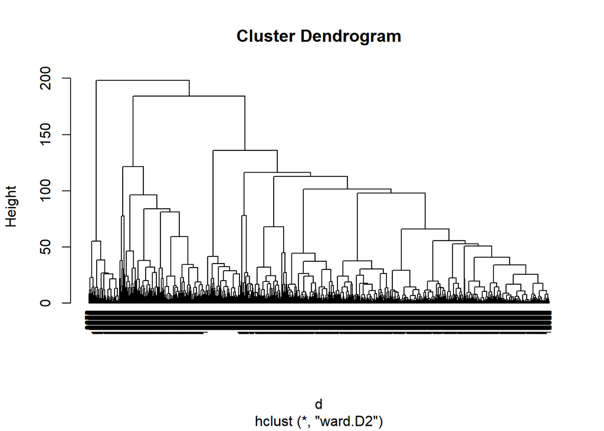

```r
# plotting the dendrogram
# ---
#
plot(res.hc, cex = 0.6, hang = -1)
```

The clusters are many and are overlapping due to the large dataset thus the dendogram is not legible making it difficult to make any deductions.

## k-Means Clustering

```r
# Modeling packages
library(cluster)     # for general clustering algorithms
library(factoextra)  # for visualizing cluster results
# Loading package
library(ClusterR)
library(cluster)
```

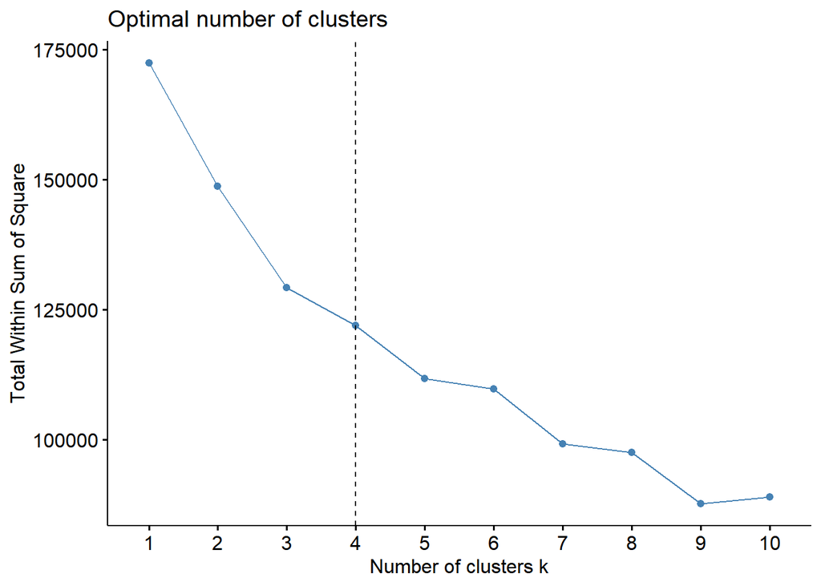

```r
# determining optimal number of clusters
fviz_nbclust(df2, kmeans, method = "wss") +
  geom_vline(xintercept = 4, linetype = 2)
```

```r
# The optimal number of clusters is 4.
```

```r
# Applying K-means with K=4

set.seed(123)
result <- kmeans(df2, 4, nstart = 25)
```

```r
# Previewing the no. of records in each cluster
result$size
```

```
## [1]  940 8909 1509  958
```

```r
# cluster means
result$centers
```

```
##   Administrative Administrative_Duration Informational Informational_Duration
## 1     -0.3767479              -0.2899312    -0.2308491             -0.1790628
## 2     -0.1488143              -0.1437119    -0.2172083             -0.1843654
## 3      1.5477439               1.3149049     1.6727594              1.3555595
## 4     -0.6843590              -0.4502368    -0.3883998             -0.2449983
##   ProductRelated ProductRelated_Duration BounceRates  ExitRates  PageValues
## 1     -0.1084637              -0.1459644 -0.01027179  0.1291789 -0.21187497
## 2     -0.1742423              -0.1610892 -0.28058724 -0.2445452  0.02377394
## 3      1.5131884               1.4237988 -0.32893796 -0.4878069  0.19310438
## 4     -0.6567024              -0.6014223  3.13755176  2.9157887 -0.31736333
##     SpecialDay OperatingSystems     Browser      Region TrafficType
## 1  3.126992519      0.036529842  0.04202702 -0.03283221   0.1627627
## 2 -0.292193989     -0.008130587  0.01308563  0.02510596  -0.0182647
## 3 -0.225756631     -0.015512673 -0.08508904 -0.10437712  -0.1168017
## 4  0.004645135      0.064202472 -0.02889967 -0.03684934   0.1941305
```

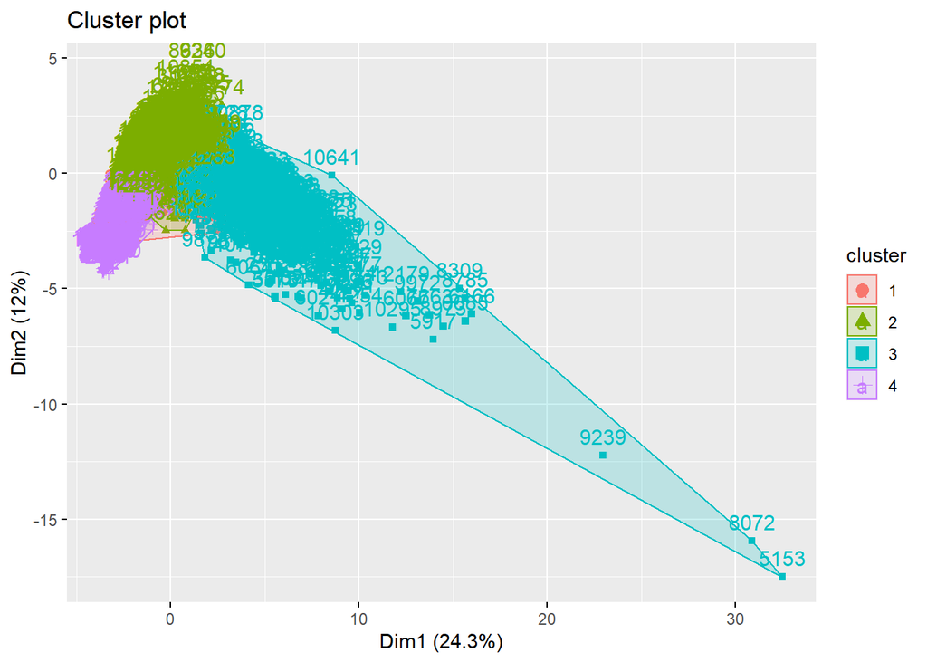

```r
# plotting the clusters(factorextra package)
fviz_cluster(result, data = df2)
```

# Conclusion and recommendations

Comparatively, the k-means clusters are visually clearer thus we recommend the customer to apply the k-means algorithm for customer analysis. Since the data set is large(more than 500 observations), k-means will also be most appropriate because hierarchical clustering does not work well with large datasets.